# ReLTER - Advanced use

Micha Silver

13/04/2022

Back to TOC

## Dependency on DEIMS-SDR

`ReLTER` relies on the data entered into DEIMS-SDR. However there are:

- Multiple sites with similiar names
- Missing information
- Sites with no boundary polygon

#### First example, the Kiskun region of Hungary

```r
# Multiple sites in the KISKUN region of Hungary
kiskun <- get_ilter_generalinfo(country_name = "Hungary",
                              site_name = "KISKUN")
# How many sites?
print(paste("In Kiskun region: ", length(kiskun$title), "sites"))
```

```
## [1] "In Kiskun region:  8 sites"
```

```r
(kiskun$title)
```

```
## [1] "Kiskun Forest Reserve Sites, KISKUN LTER - Hungary"
## [2] "VULCAN Kiskunsag, KISKUN LTER - Hungary"
## [3] "Kiskun Restoration Experiments, KISKUN LTER - Hungary"
## [4] "Kiskun Site Network (Jedlik), KISKUN LTER - Hungary"
## [5] "KISKUN LTER - Hungary"
## [6] "LTER Fulophaza Site, KISKUN LTER - Hungary"
## [7] "Bugac-Bocsa-Orgovany Site, KISKUN LTER - Hungary"
## [8] "Orgovany Site, KISKUN LTER - Hungary"
```

```r
# Which site? Bugac-Bocsa
bugac_id <- kiskun[7,]$uri
bugac_details <- get_site_info(bugac_id,"Contacts")
(bugac_details$generalInfo.siteManager[[1]]['name'])
```

```
##          name
## 1 Gábor Ónodi
```

```r
# Site manager is available

bugac_polygon <- get_site_info(bugac_id, "Boundaries")
```

```
##
## ----
## This site does not have boundaries uploaded to DEIMS-SDR.
## Please verify in the site page: https://deims.org/609e5959-8cd8-44a0-ab42-eda521cd452a
## ----
```

```r
str(bugac_polygon)
```

```
## tibble [1 × 9] (S3: tbl_df/tbl/data.frame)
##  $ title       : chr "Bugac-Bocsa-Orgovany Site, KISKUN LTER - Hungary"
##  $ uri         : chr "https://deims.org/609e5959-8cd8-44a0-ab42-eda521cd452a"
##  $ boundaries  : logi NA
##  $ geoCoord    : chr "POINT (19.5281 46.7183)"
##  $ country     :List of 1
##   ..$ : chr "Hungary"
##  $ geoElev.avg : int 112
##  $ geoElev.min : int 105
##  $ geoElev.max : int 120
##  $ geoElev.unit: chr "msl"
```

```r
# No geometry
```

- This site has the site manager’s name
- but no boundary polygon

#### Second example, Gran Paradiso in Italy

```r
paradiso <- get_ilter_generalinfo(country_name = "Italy",
                              site_name = "Gran Paradiso")
(paradiso$title)
```

```
## [1] "IT23 - Gran Paradiso National Park - Italy"
## [2] "Gran Paradiso National Park - Italy"
```

```r
# Choose the second
paradiso_id <- paradiso[2,]$uri
paradiso_details <- get_site_info(paradiso_id,"Contacts")
# Multiple names for metadata:
paradiso_details$generalInfo.metadataProvider[[1]]['name']
```

```
##                 name
## 1 Alessandro Oggioni
## 2     Ramona Viterbi
```

```r
# No funding agency
paradiso_details$generalInfo.fundingAgency
```

```
## [1] NA
```

- This site has metadata providers
- but no funding agency

## Acquiring Earth Observation data

Functions within ReLTER help to acquire certain Earth Observation datasets. The `get_site_ODS` function give `ReLTER` users access to the OpenDataScience Europe (ODS) archive (https://maps.opendatascience.eu/) with landcover, NDVI, natura2000 all at 30 meter pixel resolution. The Cropping to site boundaries is done in the cloud, and due to the Cloud Optimized Geotiff (COG) format, downloads are quite small.

```r
# Get DEIMS ID for Kis-Balaton site
kis_balaton <- get_ilter_generalinfo(country_name = "Hungary",
                              site_name = "Kis-Balaton")
kb_id = kis_balaton$uri
kb_polygon = get_site_info(kb_id, "Boundaries")

# Now acquire landcover and NDVI from OSD
kb_landcover = get_site_ODS(kb_id, dataset = "landcover")
kb_ndvi_summer = get_site_ODS(kb_id, "ndvi_summer")

# Plot maps
tm_basemap() +
  tm_shape(kb_polygon) +
  tm_borders(col = "purple") +
  tm_shape(kb_ndvi_summer) +
  tm_raster(alpha=0.7, palette = "RdYlGn")
```

[interactive chart not shown]

```r
tm_basemap() +
  tm_shape(kb_polygon) +
  tm_borders(col = "purple") +
  tm_shape(kb_landcover) +
  tm_raster(alpha=0.7, palette = "Set1")
```

[interactive chart not shown]

#### Second example, Companhia das Lezírias, Portugal

```r
lezirias <- get_ilter_generalinfo(country_name = "Portugal",
                              site_name = "Companhia")
lezirias_id = lezirias$uri
lezirias_polygon = get_site_info(lezirias_id, "Boundaries")

# Now acquire spring NDVI from OSD
lezirias_ndvi_spring = get_site_ODS(lezirias_id, "ndvi_spring")

# Plot maps
tm_basemap() +
  tm_shape(lezirias_polygon) +
  tm_borders(col = "purple") +
  tm_shape(lezirias_ndvi_spring) +
  tm_raster(alpha=0.7, palette = "RdYlGn")
```

[interactive chart not shown]

```r
# The function outputs a raster. We can save to Geotiff for use in other GIS
class(lezirias_ndvi_spring)
```

```
## [1] "SpatRaster"
## attr(,"package")
## [1] "terra"
```

```r
writeRaster(x = lezirias_ndvi_spring,
            filename = "lezirias_ndvi_spring.tif",
            overwrite = TRUE)
```

## Additional plotting functions

#### Environmental parameters

`ReLTER` has implemented some revealing visualizations of the various parameters collected at LTER sites. One visualization is the pie chart of environmental parameters.

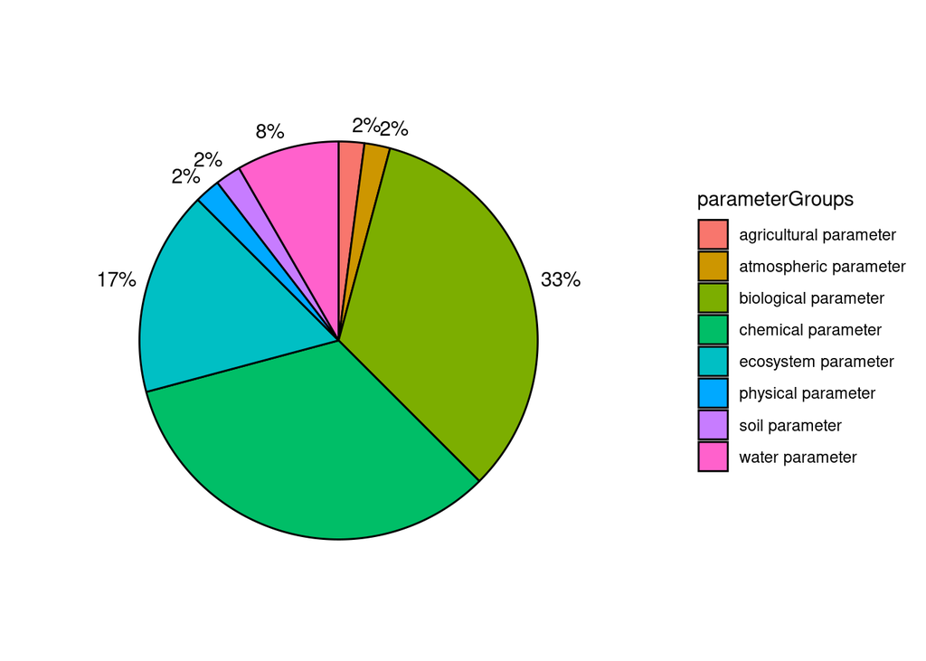

```
## # A tibble: 8 × 9
##   parameterGroups            n   freq label   end start middle hjust vjust
##   <chr>                  <int>  <dbl> <chr> <dbl> <dbl>  <dbl> <dbl> <dbl>
## 1 agricultural parameter     1 0.0208 2%    0.131 0     0.0654     0     0
## 2 atmospheric parameter      1 0.0208 2%    0.262 0.131 0.196      0     0
## 3 biological parameter      16 0.333  33%   2.36  0.262 1.31       0     0
## 4 chemical parameter        16 0.333  33%   4.45  2.36  3.40       1     1
## 5 ecosystem parameter        8 0.167  17%   5.50  4.45  4.97       1     0
## 6 physical parameter         1 0.0208 2%    5.63  5.50  5.56       1     0
## 7 soil parameter             1 0.0208 2%    5.76  5.63  5.69       1     0
## 8 water parameter            4 0.0833 8%    6.28  5.76  6.02       1     0
```

```r
produce_site_parameters_pie(kb_id)
```

Similarly, a “waffle” chart can be produced.

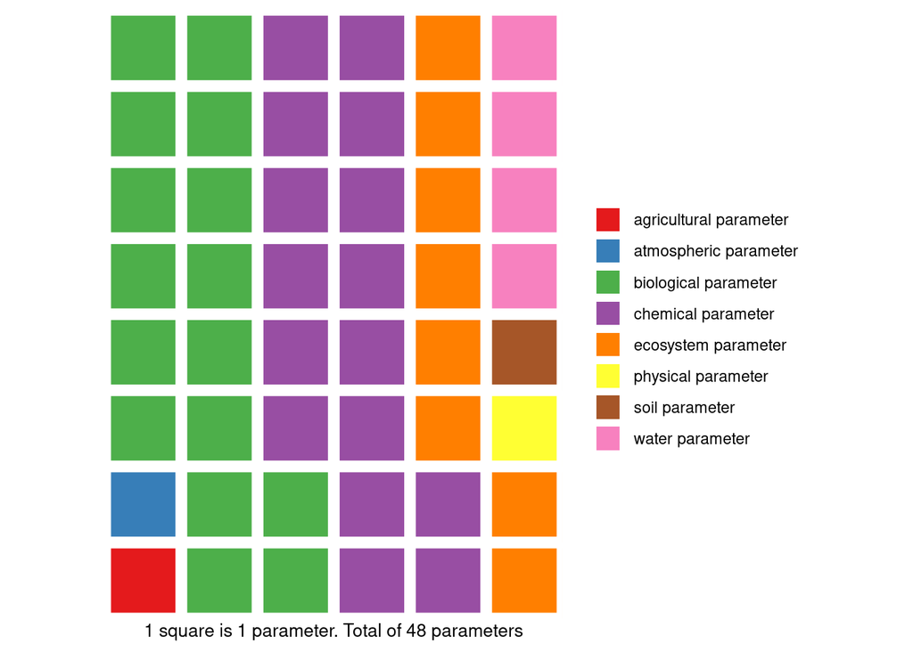

```
## # A tibble: 8 × 4
##   parameterGroups            n   freq label
##   <chr>                  <int>  <dbl> <chr>
## 1 agricultural parameter     1 0.0208 2%
## 2 atmospheric parameter      1 0.0208 2%
## 3 biological parameter      16 0.333  33%
## 4 chemical parameter        16 0.333  33%
## 5 ecosystem parameter        8 0.167  17%
## 6 physical parameter         1 0.0208 2%
## 7 soil parameter             1 0.0208 2%
## 8 water parameter            4 0.0833 8%
```

```r
produce_site_parameters_waffle(kb_id)
```

#### Research topics, Related resources

List all research topics throughout an LTER network.

List related resources for an LTER network.

We demonstrate with the LTER network in Slovakia. Then filter for “Ecosystem” research.

```r
lter_slovakia_id <- "https://deims.org/networks/3d6a8d72-9f86-4082-ad56-a361b4cdc8a0"
slv_research_topics <- get_network_research_topics(lter_slovakia_id)
ecosystem_items <- grepl(pattern = "ecosystem",
                         slv_research_topics$researchTopicsLabel,
                         fixed = TRUE)
# Here is the filtered list
slv_research_topics[ecosystem_items,]
```

```
## # A tibble: 3 × 2
##   researchTopicsLabel researchTopicsUri
##   <chr>               <chr>
## 1 ecosystem ecology   http://vocabs.lter-europe.net/EnvThes/21689
## 2 ecosystem function  http://vocabs.lter-europe.net/EnvThes/20519
## 3 ecosystem service   http://vocabs.lter-europe.net/EnvThes/20520
```

```r
# List related resources
get_network_related_resources(lter_slovakia_id)
```

```
##
## ---- The requested page could not be found.
##             Please check the DEIMS ID ----
```

```
## # A tibble: 7 × 3
##   relatedResourcesTitle                                   uri   relatedResource…
##   <chr>                                                   <chr> <chr>
## 1 Báb_temperature_precipitation_LTER_EU_SK_001_2014-2018  http… 2019-12-20T13:2…
## 2 LTER_Jalovecka dolina temperature 2003-2017             http… 2020-01-07T15:0…
## 3 LTER Jalovecka dolina precipitation 2013-2017           http… 2019-12-20T13:2…
## 4 LTER EES Kremicke vrchy climate                         http… 2019-12-20T13:2…
## 5 <NA>                                                    <NA>  <NA>
## 6 LTER Polana-Hukavsky_grun temperature precipitation 20… http… 2019-12-20T13:2…
## 7 Climate Kralova hola_LTER_EU_SK_009_2015-2018           http… 2019-12-20T13:2…
```

#### Show a map of sites in a network

This example uses the LTER network in Greece

The `produce_network_points_map()` function requires both DEIMS network ID and the three letter ISO code for the country to be mapped.

```r
lter_greece_id = "https://deims.org/networks/83453a6c-792d-4549-9dbb-c17ced2e0cc3"
produce_network_points_map(lter_greece_id, "GRC")
```

```
## Simple feature collection with 8 features and 3 fields
## Geometry type: POINT
## Dimension:     XY
## Bounding box:  xmin: 21.65605 ymin: 35.33772 xmax: 26.24096 ymax: 40.45687
## Geodetic CRS:  WGS 84
## # A tibble: 8 × 4
##   title                                  uri   changed         coordinates
## * <chr>                                  <chr> <chr>           <POINT [°]>
## 1 LTSER Platform Koiliaris Critical Zon… http… 2021-1… (24.08993 35.41344)
## 2 LTSER Platform Hydrologic Observatory… http… 2021-1… (23.69888 38.04697)
## 3 Navarino Environmental Observatory - … http… 2021-1… (21.65605 36.99325)
## 4 Finokalia Atmospheric Observatory - G… http… 2021-1… (25.66975 35.33772)
## 5 Lesvos Biodiversity Observatory - Gre… http… 2021-1… (26.24096 39.16725)
## 6 Pinios Hydrologic Observatory - Greece http… 2021-1… (22.76484 39.71307)
## 7 LTSER Platform Samothraki Nature Obse… http… 2021-1… (25.57823 40.45687)
## 8 Sani Environmental Observatory - Gree… http… 2022-0… (23.31445 40.10869)
```

Back to TOC